# Chicago Hospital Metadata

2023-06-05

# Metadata from SRA project PRJEB14474

The full metadata table is very tedious to look through. I want to pick out the columns that might be informative in reanalyzing the data to save as a smaller table. Along the way, I want to get an idea of what I have to work with.

```r
suppressPackageStartupMessages(library(dplyr))
library(tidyr)
library(dplyr)
library(ggplot2)
library(ggrepel)
```

```r
data = read.delim2("../../data/NOT_IN_GIT/meta/PRJEB14474_SraRunTable.txt")
row.names(data) = data$ID
```

Save any output to this folder:

```r
outDir = "../output"
suppressWarnings(dir.create(outDir))
```

## Modify some data

### Date

Convert the Date values into sortable numeric values.

```r
ds = strsplit(data$Date, split="/")
ds2 = do.call(rbind, ds) %>% data.frame()
row.names(ds2) = data$ID
names(ds2) = c("month", "day", "year")
ds2$monthC = as.character(ds2$month)
need0 = as.numeric(ds2$month) < 10
ds2$monthC[need0] = paste0("0", ds2$month[need0])
ds2$datestring = paste0("20", ds2$year, "-", ds2$monthC, "-", ds2$day)
ds2$date = as.Date(ds2$datestring)
ds2$thDay = as.numeric( ds2$date - min(ds2$date) )
```

```r
head(ds2)
```

```
##            month day year monthC datestring       date thDay
## ERR1459321     2  28   13     02 2013-02-28 2013-02-28    85
## ERR1459322     2  28   13     02 2013-02-28 2013-02-28    85
## ERR1459323     2  28   13     02 2013-02-28 2013-02-28    85
## ERR1459324     2  28   13     02 2013-02-28 2013-02-28    85
## ERR1459325     2  28   13     02 2013-02-28 2013-02-28    85
## ERR1459326     2  28   13     02 2013-02-28 2013-02-28    85
```

### host_subject_id

This id column seems to have 3 parts separated by “.”.

```r
head(data$host_subject_id)
```

```
## [1] "R9016.Nose.4"          "R9016.Inguinal Fold.4" "R9016.Bedrail.4"
## [4] "R9016.Floor.4"         "R10016.Bedrail.4"      "R10016.Floor.4"
```

First looks like location, second looks like sample type, and third is an integer. Not sure what that means. Lets grab it and check it out.

```r
data$hsi3 = sapply(strsplit(data$host_subject_id, split=".", fixed=T),
             "[", 3)
data$hsi3 = as.numeric(data$hsi3)
summary(data$hsi3)
```

```
##    Min. 1st Qu.  Median    Mean 3rd Qu.    Max.
##   -81.0    24.0   104.0   122.5   211.0   325.0
```

Lets see if it is correlated with any other data.

```r
ds3 = merge(ds2, data["hsi3"], by=0)
row.names(ds3) = ds3$Row.names
ds3 = ds3[,grep(x=names(ds3), "Row.names", value=T, invert = T)]
```

```r
table(ds3$thDay - ds3$hsi3 == 81)
```

```
##
## TRUE
## 3079
```

Oh! I guess this number refers to integer day.

And maybe 0 is the day the hospital opened? The paper says

> Sampling began 2 months before the hospital opening on 23 February 2013 and continued for a year thereafter.

```r
is0 = which(ds3$hsi3 == 0 )
ds3$date[is0] %>% unique()
```

```
## [1] "2013-02-24"
```

Expected Feb 23, and seeing Feb 24… Close enough! Lets call this “study_day”.

```r
ds3$study_day = ds3$hsi3
```

### Submitter Id

In an individual email correspondence, I asked the authors for patient IDs. They generously sent a mapping file.

The “SampleID” in that file, corresponds to the second half of the “Library Name” column in this metadata. Unfortunately, using that, I found that some values that should have been “1000” were represented as “1”, it looks like the issue is somewhere upstream of the sra metadata. Fortunately, the “Submitter_Id” field has a qiita identifier, that also includes this id and it has the “1000” value. Use that instead.

```r
data = data %>%
  mutate(internalID = sapply(strsplit(Submitter_Id, split=".", fixed=T), "[[", 2 ) ) %>%
  mutate(preID = sapply(strsplit(Submitter_Id, split=".", fixed=T), "[[", 1 ) )

unique(data$preID)
```

```
## [1] "qiita_sid_10172:10172"
```

The part of the qiita identifier ahead of the sample id is the same for all samples, so we can drop that. We’ll hold on to this “internalID” column to easily merge to the mapping file.

## Reduced data frame

Select limited columns.

```r
df = merge(data, ds3, by=0)
df2 = df[,c("ID", "Sample.Name", "Sample_name", "host_subject_id", "internalID", "Date", "study_day", "SAMPLE_TYPE", "Location", "run_prefix..exp.", "env_material", "surcat", "Bases", "AvgSpotLen")]
```

Give a value to the blank run prefix.

```r
blankVals = df2$run_prefix..exp. == ""
df2$run_prefix..exp.[blankVals] = "otherRun"
```

```r
write.table(file = file.path(outDir, "PRJEB14474_SraRunTable_reduced.txt"),
            df2, quote=F, row.names = F, sep="\t")
```

## Visually summarize

### sample number by type, time, location

Location vs SAMPLE_TYPE

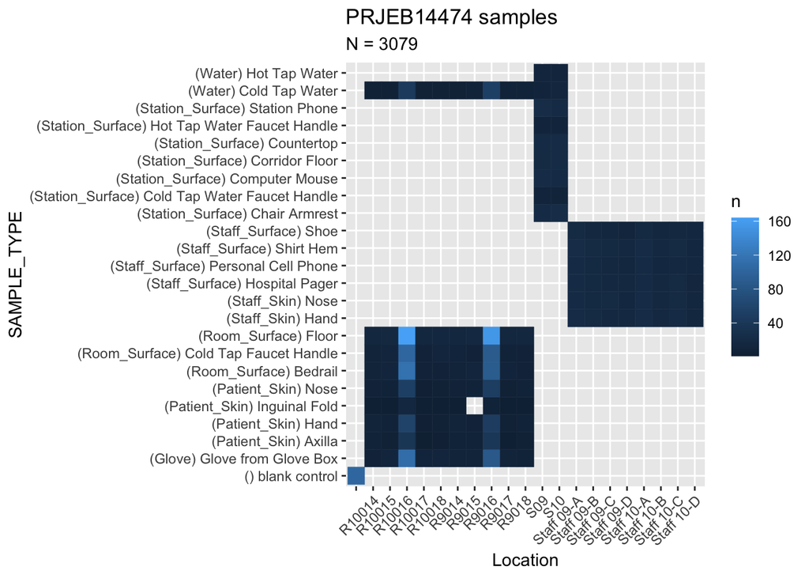

```r
df7 = df2 %>%
  mutate(SAMPLE_TYPE = paste0("(", surcat, ") ", SAMPLE_TYPE)) %>%
  count(SAMPLE_TYPE, Location)

hm = ggplot(df7, aes(x=Location, y=SAMPLE_TYPE, color=n, fill=n)) +
  geom_tile() +
  theme(axis.text.x = element_text(angle = 45, vjust = 1, hjust=1)) +
  ggtitle("PRJEB14474 samples", subtitle = paste("N =", sum(df7$n)))
hm
```

```r
ggsave(file.path(outDir, "Locatoin-sampletype_heat.png"), hm)
write.table(df7 %>%
              mutate_all(function(x) replace(x, x=='', NA)) %>%
              pivot_wider(names_from = Location, values_from = "n" ),
            file = file.path(outDir, "Location-sampletype_table.txt"),
            quote=F, sep="\t", row.names = F)
```

I guess the ‘blank control’ samples are not assigned a location.

Repeat, but only consider unque samples.

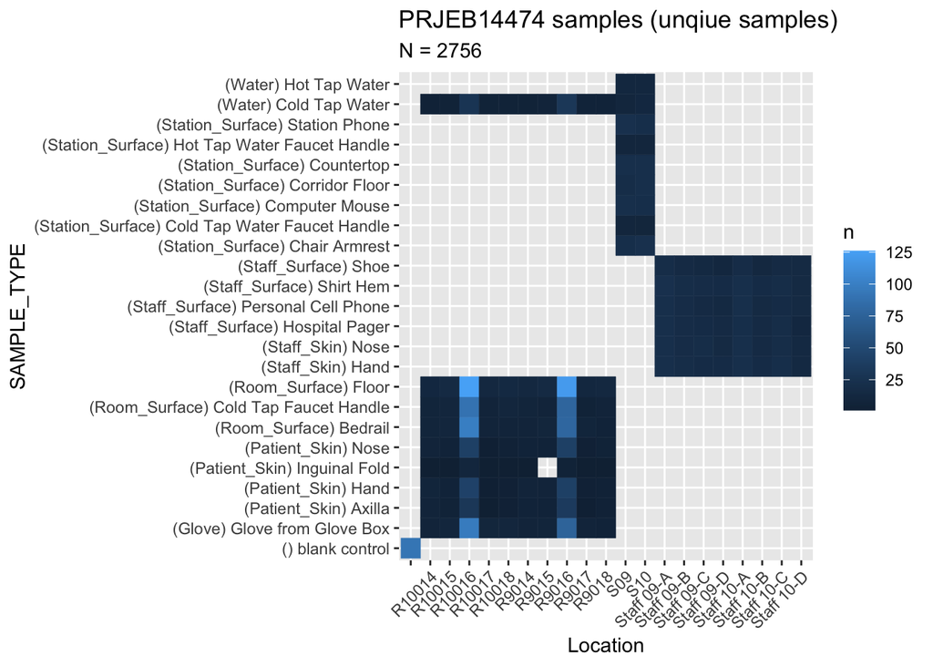

```r
df8.u = df2 %>%
  filter(!duplicated(Sample.Name)) %>%
  mutate(SAMPLE_TYPE = paste0("(", surcat, ") ", SAMPLE_TYPE)) %>%
  count(SAMPLE_TYPE, Location)

hm.u = ggplot(df8.u, aes(x=Location, y=SAMPLE_TYPE, color=n, fill=n)) +
  geom_tile() +
  theme(axis.text.x = element_text(angle = 45, vjust = 1, hjust=1)) +
  ggtitle("PRJEB14474 samples (unqiue samples)", subtitle = paste("N =", sum(df8.u$n)))
ggsave(file.path(outDir, "Locatoin-sampletype_heat_unique.png"), hm.u)
hm.u
```

That looks pretty much the same. Where are the technical replicates?

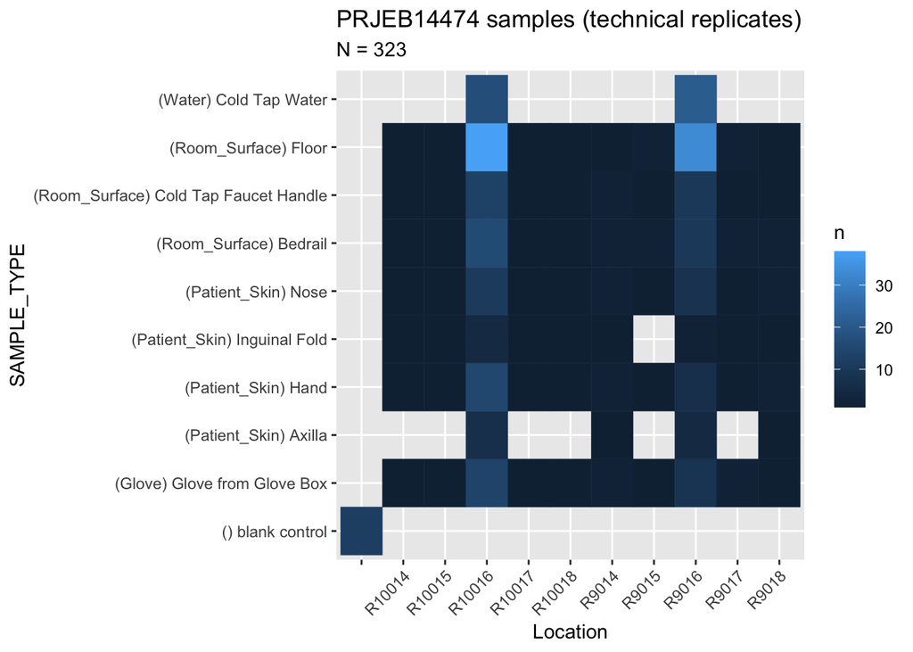

```r
df8.d = df2 %>%
  filter(duplicated(Sample.Name)) %>%
  mutate(SAMPLE_TYPE = paste0("(", surcat, ") ", SAMPLE_TYPE)) %>%
  count(SAMPLE_TYPE, Location)

hm.d = ggplot(df8.d, aes(x=Location, y=SAMPLE_TYPE, color=n, fill=n)) +
  geom_tile() +
  theme(axis.text.x = element_text(angle = 45, vjust = 1, hjust=1)) +
  ggtitle("PRJEB14474 samples (technical replicates)", subtitle = paste("N =", sum(df8.d$n)))
hm.d
```

Sampling over time.

Visually, how many of each type of sample were collected each day?

```r
df3 = df2 %>% count(study_day, SAMPLE_TYPE)
# ggplot(df3) +
#   geom_tile(aes(x=study_day, y=SAMPLE_TYPE, color=n, fill=n)) +
#   scale_color_gradient(low="blue", high="red") +
#   scale_fill_gradient(low="blue", high="red")
```

That’s so fine its hard to read.

What if we lump together samples collected in a 10-day period?

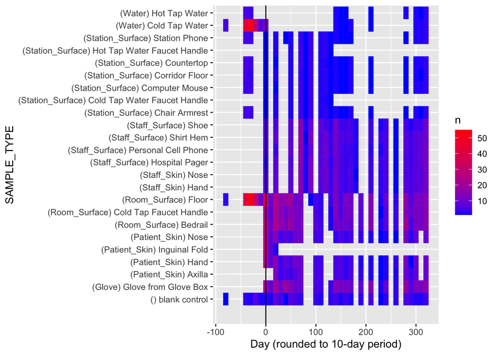

```r
df4 = df2 %>%
  mutate(SAMPLE_TYPE = paste0("(", surcat, ") ", SAMPLE_TYPE)) %>%
  mutate(ishDay=round(study_day, -1)) %>%
  count(ishDay, SAMPLE_TYPE)

byday = ggplot(df4) +
  geom_tile(aes(x=ishDay, y=SAMPLE_TYPE, color=n, fill=n)) +
  scale_color_gradient(low="blue", high="red") +
  scale_fill_gradient(low="blue", high="red") +
  xlab("Day (rounded to 10-day period)") +
  geom_vline(xintercept = 0,
             linetype = "solid") +
  annotate(geom = "text",
             label = " opening",
             x = 0, y=-1,
             vjust = 1, hjust=0)
# +
  # coord_cartesian(ylim = c(0, 23), clip = "off")
byday
```

```r
ggsave(file.path(outDir, "time-sampletype_heat.png"), byday)
```

For each sample type, how are samples distributed over time?

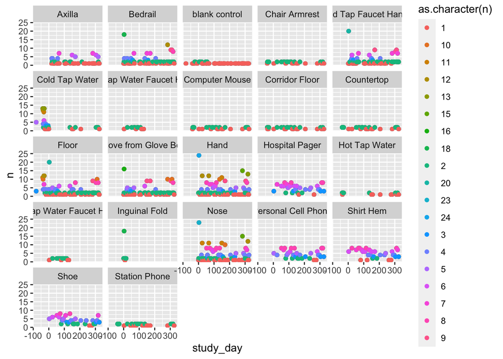

```r
p2 = ggplot(df3, aes(x=study_day, y=n)) +
  geom_point() +
  facet_wrap(facets="SAMPLE_TYPE") +
  geom_point(aes(color=as.character(n))) + scale_color_hue()
p2
```

Location sampling over time

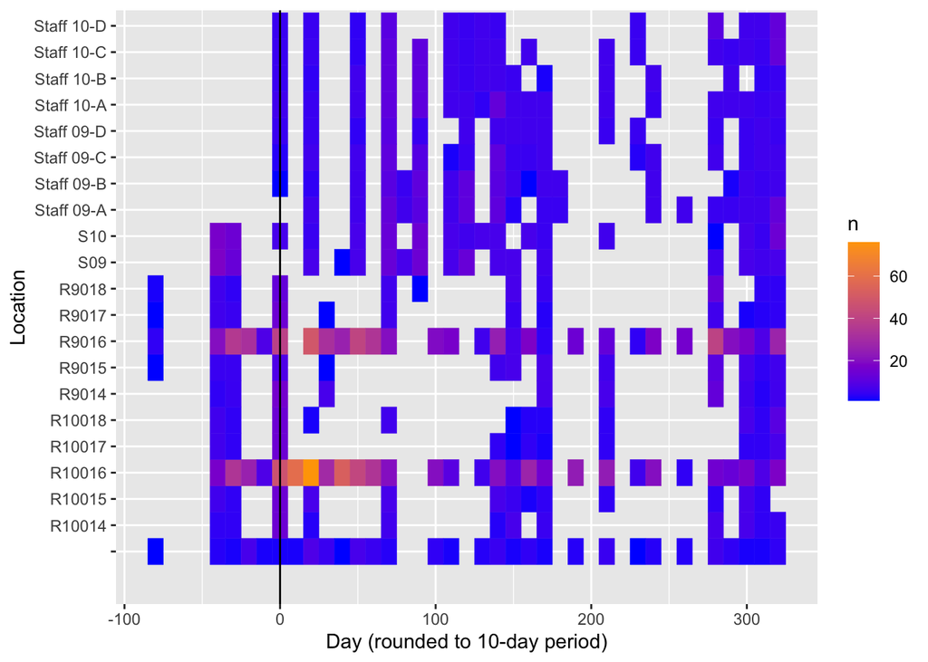

```r
df9 = df2 %>%
  mutate(ishDay=round(study_day, -1)) %>%
  count(ishDay, Location)

byday = ggplot(df9) +
  geom_tile(aes(x=ishDay, y=Location, color=n, fill=n)) +
  scale_color_gradient(low="blue", high="orange") +
  scale_fill_gradient(low="blue", high="orange") +
  xlab("Day (rounded to 10-day period)") +
  geom_vline(x = 0,
             xintercept = 0,
             linetype = "solid") +
  annotate(geom = "text",
             label = " opening",
             x = 0, y=-1,
             vjust = 1, hjust=0)
byday
```

```r
ggsave(file.path(outDir, "time-location_heat.png"), byday)
```

Specifically for the patient surface samples, for each type, what location / time distribution do I have? Does it look like it might be enough into to infer when the patient changes?

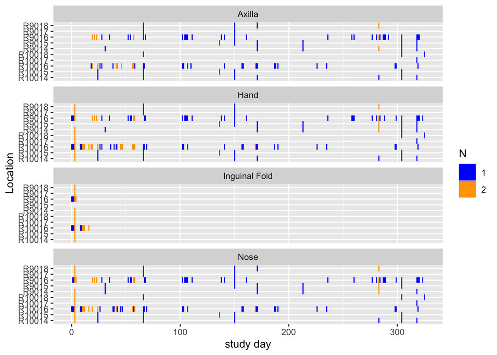

```r
colorScale = c("blue", "orange", "darkgreen", "pink", "hotpink", "darkred")

df9.2 = df2 %>%
  filter(surcat == "Patient_Skin") %>%
  #filter(SAMPLE_TYPE == "Hand") %>%
  count(study_day, Location, SAMPLE_TYPE) %>%
  mutate(N=as.factor(n))

byday2 = ggplot(df9.2) +
  geom_tile(aes(x=study_day, y=Location, fill=N)) +
  scale_fill_discrete(type=colorScale) +
  xlab("study day") +
  # theme_get() +
  facet_wrap("SAMPLE_TYPE", ncol = 1)

ggsave(file.path(outDir, "patient-skin_time.v.location_sample-count.png"), byday2)
byday2
```

A lot of those, look like the different sample types were taken on the same day. Plot them all together to see if they do indeed line up.

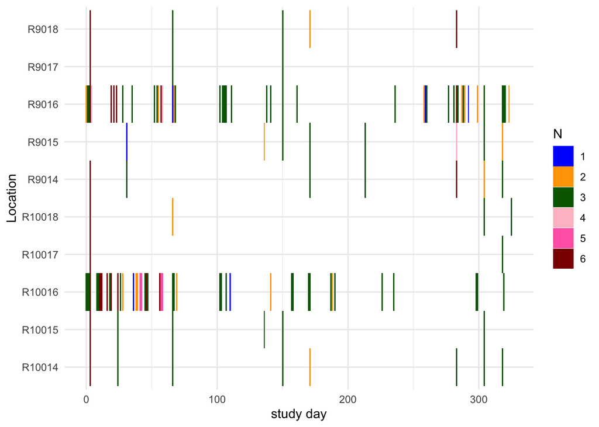

```r
df9.1 = df2 %>%
  filter(surcat == "Patient_Skin") %>%
  count(study_day, Location) %>%
  mutate(N=as.factor(n))

byday1 = ggplot(df9.1) +
  geom_tile(aes(x=study_day, y=Location, fill=N)) +
  scale_fill_discrete(type=colorScale) +
  xlab("study day") +
  theme_minimal()
byday1
```

Yup, as expected, the gaps from the individual samples types are still the gaps when they are all together.

Save one iteration that is just the plot for the hand data.

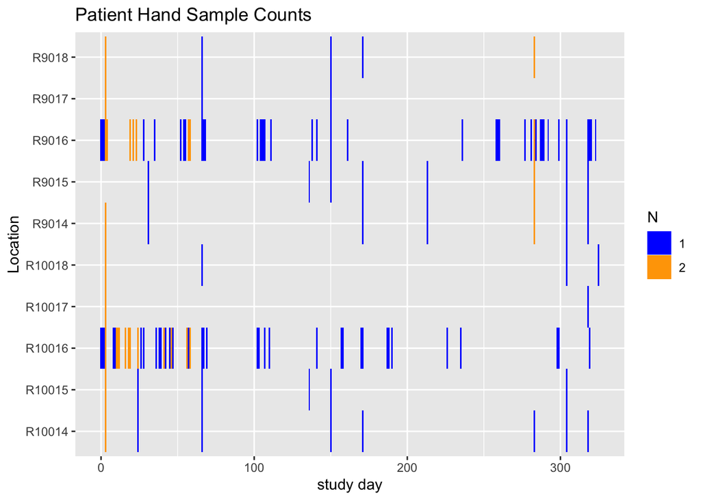

```r
df9.hand = df2 %>%
  filter(SAMPLE_TYPE == "Hand") %>%
  count(study_day, Location, SAMPLE_TYPE) %>%
  mutate(N=as.factor(n))

byday4 = ggplot(df9.2) +
  geom_tile(aes(x=study_day, y=Location, fill=N)) +
  scale_fill_discrete(type=colorScale) +
  xlab("study day") +
  ggtitle("Patient Hand Sample Counts")

ggsave(file.path(outDir, "patient-hand_time.v.location_sample-count.png"), byday4, height = 2.2)
byday4
```

### Bases per sample type

```r
data %>%
  count(AvgSpotLen, run_prefix..exp.) %>%
  mutate_at(c("AvgSpotLen", "run_prefix..exp."), function(x) replace(x, x=='', "unknown")) %>%
  pivot_wider(names_from = run_prefix..exp., values_from= n)
```

```
## # A tibble: 20 × 9
##    AvgSpotLen HiSeq1_8 HiSeq2_4 unknown HiSeq2_7 HiSeq1_4 HiSeq2_3 MiSeq1 MiSeq3
##    <chr>         <int>    <int>   <int>    <int>    <int>    <int>  <int>  <int>
##  1 119               1       NA      NA       NA       NA       NA     NA     NA
##  2 121               6       NA      NA       NA       NA       NA     NA     NA
##  3 122             879       NA      NA       NA       NA       NA     NA     NA
##  4 123              NA        1      NA       NA       NA       NA     NA     NA
##  5 124              NA        5      NA       NA       NA       NA     NA     NA
##  6 125              NA       19      NA       NA       NA       NA     NA     NA
##  7 126              NA       36       5       NA       NA       NA     NA     NA
##  8 127              NA       22     113        2       NA       NA     NA     NA
##  9 128              NA        4     308      124       NA       NA     NA     NA
## 10 129              NA        1       6      236       NA       NA     NA     NA
## 11 130              NA        1       1      121       NA       NA     NA     NA
## 12 131              NA       NA       1       18       NA       NA     NA     NA
## 13 132              NA       NA      NA        3       NA       NA     NA     NA
## 14 133              NA       NA      NA        1       NA       NA     NA     NA
## 15 144              NA       NA      NA       NA        1       NA     NA     NA
## 16 147              NA       NA      NA       NA       NA        1     NA     NA
## 17 148              NA       NA      NA       NA       NA       27     NA     NA
## 18 149              NA       NA      NA       NA       NA       61     NA     NA
## 19 150              NA       NA      NA       NA       NA       NA      4     NA
## 20 151              NA       NA      NA       NA       NA       NA    468    603
```

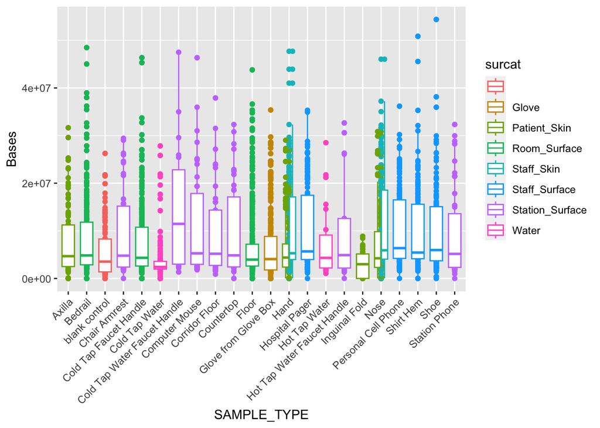

```r
p1 = ggplot(data, aes(x=SAMPLE_TYPE, y=Bases, color=surcat)) +
  geom_point() +
  theme(axis.text.x = element_text(angle = 45, vjust = 1, hjust=1))

p1 + geom_boxplot()
```

Of the subset that I used for testing, which samples have the most bases?

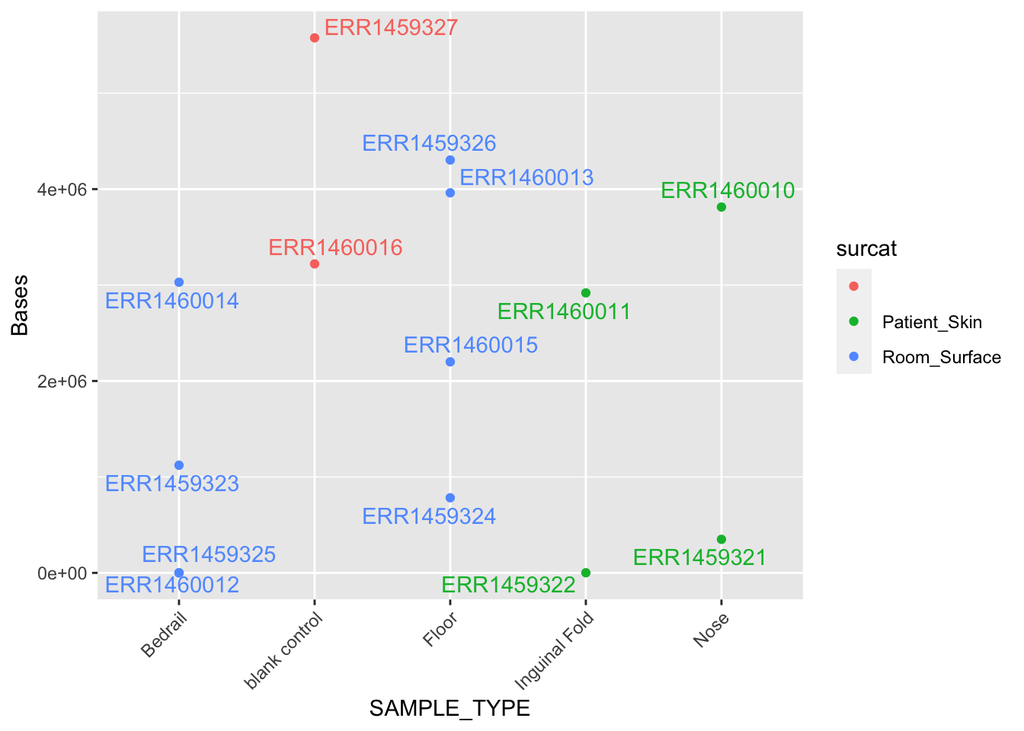

```r
subset = df2 %>% filter(df$study_day==4)
subsetPlot = ggplot(subset, aes(x=SAMPLE_TYPE, y=Bases, color=surcat)) +
  geom_point() +
  theme(axis.text.x = element_text(angle = 45, vjust = 1, hjust=1))
# subsetPlot + geom_text(aes(label=ID, vjust=-.5))
# subsetPlot + geom_label(aes(label=ID, vjust=-.5))
subsetPlot + geom_text_repel(aes(label = ID), show.legend = FALSE)
```

```r
# three cheers for the ggrepel package! otherwise the labels for ERR1460012 and ERR1459325 would cover each other!
```

Well, fiddles. I gave the intern a subset where the blanks are some of the largest samples and some of the actual samples are essentially empty.

## Which columns are redundant

### SAMPLE_TYPE = surface

Is there any difference between the “SAMPLE_TYPE” column and the “surface” column?

```r
ns = which(data$surface != data$SAMPLE_TYPE)
cotype = paste(data$surface[ns], data$SAMPLE_TYPE[ns])
table(cotype)
```

```
## cotype
## BLANK blank control
##                 103
```

No. SAMPLE_TYPE and surface are the same. One uses the term BLANK the other says “blank control”, otherwise identical.

What are the values of the “SAMPLE_TYPE” feature? How often does each value appear?

```r
table(data$SAMPLE_TYPE)
```

```
##
##                       Axilla                      Bedrail
##                          114                          278
##                blank control                Chair Armrest
##                          103                           43
##       Cold Tap Faucet Handle               Cold Tap Water
##                          262                          162
## Cold Tap Water Faucet Handle               Computer Mouse
##                           19                           42
##               Corridor Floor                   Countertop
##                           41                           43
##                        Floor         Glove from Glove Box
##                          435                          270
##                         Hand               Hospital Pager
##                          304                          139
##                Hot Tap Water  Hot Tap Water Faucet Handle
##                           22                           20
##                Inguinal Fold                         Nose
##                           36                          294
##          Personal Cell Phone                    Shirt Hem
##                          137                          150
##                         Shoe                Station Phone
##                          122                           43
```

There are 22 values. “glove from box” might be considered additional blanks.

### Location = loccat

Is there any difference between “Location” and “loccat”?

```r
table(data$Location == data$loccat)
```

```
##
## TRUE
## 3079
```

No. Those are synonymous features.

What are the values for Location? How often do they appear?

```r
table(data$Location)
```

```
##
##                R10014     R10015     R10016     R10017     R10018      R9014
##        103         69         75        701         54         64         73
##      R9015      R9016      R9017      R9018        S09        S10 Staff 09-A
##         73        613         56         63        146        149        127
## Staff 09-B Staff 09-C Staff 09-D Staff 10-A Staff 10-B Staff 10-C Staff 10-D
##        108        101         90        125         94        110         85
```

### run_prefix and run_date

Is there a relationship between “run_prefix..exp.” and “target_gene..exp.” ?

```r
data %>%
  count(target_gene..exp., run_prefix..exp.) %>%
  mutate_at(c("target_gene..exp.", "run_prefix..exp."), function(x) replace(x, x=='', "unknown")) %>%
  pivot_wider(names_from = run_prefix..exp., values_from= n)
```

```
## # A tibble: 2 × 9
##   target_gene..exp. HiSeq1_4 HiSeq1_8 HiSeq2_3 HiSeq2_4 HiSeq2_7 MiSeq3 unknown
##   <chr>                <int>    <int>    <int>    <int>    <int>  <int>   <int>
## 1 16S                      1      886       89       89      505    603      NA
## 2 16S rRNA                NA       NA       NA       NA       NA     NA     434
## # ℹ 1 more variable: MiSeq1 <int>
```

This is probably just a data-entry artifact. Only the run_prefix is meaningful–if it really different sequencing. Notice that “target_subfragment..exp.” is always V4.

Is run_date..exp. interesting?

```r
dats = split(data, f=data$run_date..exp.)
# lapply(dats, function(df) unique(df$SAMPLE_TYPE))
# lapply(dats, function(df) unique(df$Location))
lapply(dats, function(df) unique(df$run_prefix..exp.))
```

```
## $`2/28/09`
## [1] ""
##
## $`3/1/13`
## [1] "MiSeq1"   "HiSeq1_4" "HiSeq2_4" "HiSeq1_8" "HiSeq2_3" "MiSeq3"   "HiSeq2_7"
```

```r
# lapply(dats, function(df) unique(df$Date) %>% sort())
```

I had assumed run_date would be the date the sample was run on the sequencer. I wonder if a subset of samples was a different data entry batch so they have “16S rRNA” instead of “16S”, and they don’t specify a run_prefix and the date was entered incorrectly (could be the date was set incorrectly in the sequencer?).

Does run_prefix have any relationship with Location?

```r
data %>%
  count(Location, run_prefix..exp.) %>%
  mutate_at(c("Location", "run_prefix..exp."), function(x) replace(x, x=='', "unknown")) %>%
  pivot_wider(names_from = run_prefix..exp., values_from= n)
```

```
## # A tibble: 21 × 9
##    Location unknown HiSeq1_8 HiSeq2_7 MiSeq1 MiSeq3 HiSeq2_3 HiSeq2_4 HiSeq1_4
##    <chr>      <int>    <int>    <int>  <int>  <int>    <int>    <int>    <int>
##  1 unknown       13       32       14     22     22       NA       NA       NA
##  2 R10014         7       20       17     NA     11        7        7       NA
##  3 R10015         8       18       18     NA     17        7        7       NA
##  4 R10016        65      140       71    255    156        7        7       NA
##  5 R10017         4       12       14     NA     10        7        7       NA
##  6 R10018         4       14       20     NA     12        7        7       NA
##  7 R9014          7       13        9     NA     18       13       13       NA
##  8 R9015          6       26       12     NA     13        8        8       NA
##  9 R9016         63      148       69    195    114       12       12       NA
## 10 R9017         NA       12       12     NA     12       10       10       NA
## # ℹ 11 more rows
```

Does run_prefix have any relationship with SAMPLE_TYPE?

```r
data %>%
  count(SAMPLE_TYPE, run_prefix..exp.) %>%
  mutate_at(c("SAMPLE_TYPE", "run_prefix..exp."), function(x) replace(x, x=='', "unknown")) %>%
  pivot_wider(names_from = run_prefix..exp., values_from= n)
```

```
## # A tibble: 22 × 9
##    SAMPLE_TYPE         unknown HiSeq1_8 HiSeq2_3 HiSeq2_4 HiSeq2_7 MiSeq1 MiSeq3
##    <chr>                 <int>    <int>    <int>    <int>    <int>  <int>  <int>
##  1 Axilla                   15       36        3        3       23     18     16
##  2 Bedrail                  33       74       14       14       44     66     33
##  3 Chair Armrest             9       12       NA       NA        8     NA     14
##  4 Cold Tap Faucet Ha…      29       78       12       12       46     54     31
##  5 Cold Tap Water            1        8       NA       NA        8     50     95
##  6 Cold Tap Water Fau…       7        3       NA       NA        4     NA      5
##  7 Computer Mouse            9       12       NA       NA        9     NA     12
##  8 Corridor Floor            8       12       NA       NA        8     NA     13
##  9 Countertop                9       11       NA       NA        9     NA     14
## 10 Floor                    30       78       13       13       48    127    125
## # ℹ 12 more rows
## # ℹ 1 more variable: HiSeq1_4 <int>
```

Does run_prefix have any relationship with AvgSpotLen?

```r
data %>%
  count(AvgSpotLen, run_prefix..exp.) %>%
  mutate_at(c("AvgSpotLen", "run_prefix..exp."), function(x) replace(x, x=='', "unknown")) %>%
  pivot_wider(names_from = run_prefix..exp., values_from= n)
```

```
## # A tibble: 20 × 9
##    AvgSpotLen HiSeq1_8 HiSeq2_4 unknown HiSeq2_7 HiSeq1_4 HiSeq2_3 MiSeq1 MiSeq3
##    <chr>         <int>    <int>   <int>    <int>    <int>    <int>  <int>  <int>
##  1 119               1       NA      NA       NA       NA       NA     NA     NA
##  2 121               6       NA      NA       NA       NA       NA     NA     NA
##  3 122             879       NA      NA       NA       NA       NA     NA     NA
##  4 123              NA        1      NA       NA       NA       NA     NA     NA
##  5 124              NA        5      NA       NA       NA       NA     NA     NA
##  6 125              NA       19      NA       NA       NA       NA     NA     NA
##  7 126              NA       36       5       NA       NA       NA     NA     NA
##  8 127              NA       22     113        2       NA       NA     NA     NA
##  9 128              NA        4     308      124       NA       NA     NA     NA
## 10 129              NA        1       6      236       NA       NA     NA     NA
## 11 130              NA        1       1      121       NA       NA     NA     NA
## 12 131              NA       NA       1       18       NA       NA     NA     NA
## 13 132              NA       NA      NA        3       NA       NA     NA     NA
## 14 133              NA       NA      NA        1       NA       NA     NA     NA
## 15 144              NA       NA      NA       NA        1       NA     NA     NA
## 16 147              NA       NA      NA       NA       NA        1     NA     NA
## 17 148              NA       NA      NA       NA       NA       27     NA     NA
## 18 149              NA       NA      NA       NA       NA       61     NA     NA
## 19 150              NA       NA      NA       NA       NA       NA      4     NA
## 20 151              NA       NA      NA       NA       NA       NA    468    603
```

The samples with prefix “MiSeq” have avg spot lengths of 150-151. All of the ones that start with “HiSeq” have ave spot length <150. I’m not sure why there is a relationship between different HiSeq prefix sets and different spot lengths.

### Date = COLLECTION_TIMESTAMP

Is there any difference between “Date” and “COLLECTOIN_TIMESTAMP”

```r
table(data$Date == gsub(" 12:00", "", data$COLLECTION_TIMESTAMP))
```

```
##
## TRUE
## 3079
```

COLLECTOIN_TIMESTAMP includes ” 12:00” at the end of the Date value.

### run_prefix vs Date

Does run_prefix have any relationship with Date?

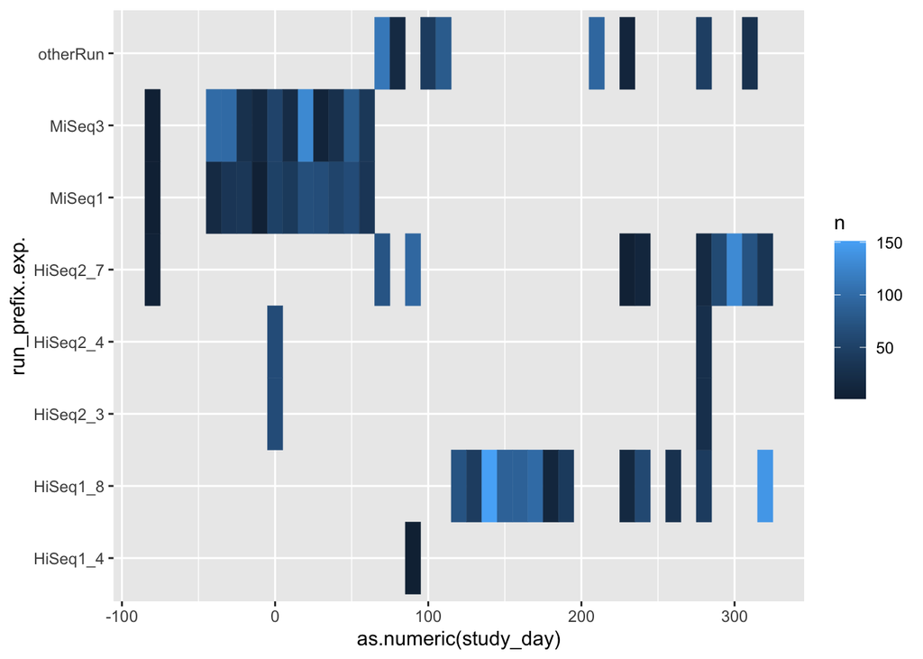

```r
df5 = df2 %>%
  mutate_at(c("study_day"), function(x) round(x, -1)) %>%
  count(study_day, run_prefix..exp.) %>%
  mutate_at(c("study_day", "run_prefix..exp."), function(x) replace(x, x=='', "unknown"))

ggplot(df5, aes(x=as.numeric(study_day), y=run_prefix..exp., color=n, fill=n)) +
  geom_tile()
```

```r
# df5 %>% pivot_wider(names_from = run_prefix..exp., values_from= n)
```

### env_biome

Is env_biome interesting?

```r
table(data$env_biome)
```

```
##
## urban biome
##        3079
```

Nope. not interesting.

### env_feature

Is env_feature interesting?

```r
feats = split(data, f=data$env_feature)
lapply(feats, function(df) unique(df$SAMPLE_TYPE))
```

```
## $hospital
##  [1] "Bedrail"                      "Floor"
##  [3] "Cold Tap Faucet Handle"       "Glove from Glove Box"
##  [5] "Cold Tap Water"               "Shirt Hem"
##  [7] "Shoe"                         "Personal Cell Phone"
##  [9] "Countertop"                   "Computer Mouse"
## [11] "Station Phone"                "Chair Armrest"
## [13] "Corridor Floor"               "Hot Tap Water Faucet Handle"
## [15] "Cold Tap Water Faucet Handle" "Hospital Pager"
## [17] "Hot Tap Water"
##
## $`human-associated habitat`
## [1] "Nose"          "Inguinal Fold" "Hand"          "Axilla"
##
## $`research facility`
## [1] "blank control"
```

No, env_feature is a grouping or category of SAMPLE_TYPE; SAMPLE_TYPE is a sub-type of env_feature. not interesting.

### env_material

Is env_material interesting?

```r
mats = split(data, f=data$env_material)
lapply(mats, function(df) unique(df$SAMPLE_TYPE))
```

```
## $`anthropogenic environmental material`
## [1] "Shirt Hem" "Shoe"
##
## $sebum
## [1] "Nose"          "Inguinal Fold" "Hand"          "Axilla"
##
## $`sterile water`
## [1] "blank control"
##
## $`surface layer`
##  [1] "Bedrail"                      "Floor"
##  [3] "Cold Tap Faucet Handle"       "Glove from Glove Box"
##  [5] "Personal Cell Phone"          "Countertop"
##  [7] "Computer Mouse"               "Station Phone"
##  [9] "Chair Armrest"                "Corridor Floor"
## [11] "Hot Tap Water Faucet Handle"  "Cold Tap Water Faucet Handle"
## [13] "Hospital Pager"
##
## $water
## [1] "Cold Tap Water" "Hot Tap Water"
```

Not really, env_material is a grouping or category of SAMPLE_TYPE; SAMPLE_TYPE is a sub-type of env_material not interesting. But, a helpful category, so lets keep it.

### surcat

Is surcat interesting?

```r
surcats = split(data, f=data$surcat)
lapply(surcats, function(df) unique(df$SAMPLE_TYPE))
```

```
## [[1]]
## [1] "blank control"
##
## $Glove
## [1] "Glove from Glove Box"
##
## $Patient_Skin
## [1] "Nose"          "Inguinal Fold" "Hand"          "Axilla"
##
## $Room_Surface
## [1] "Bedrail"                "Floor"                  "Cold Tap Faucet Handle"
##
## $Staff_Skin
## [1] "Hand" "Nose"
##
## $Staff_Surface
## [1] "Shirt Hem"           "Shoe"                "Personal Cell Phone"
## [4] "Hospital Pager"
##
## $Station_Surface
## [1] "Countertop"                   "Computer Mouse"
## [3] "Station Phone"                "Chair Armrest"
## [5] "Corridor Floor"               "Hot Tap Water Faucet Handle"
## [7] "Cold Tap Water Faucet Handle"
##
## $Water
## [1] "Cold Tap Water" "Hot Tap Water"
```

Yes! surcat is interesting because it distinguishes staff skin from patient skin for “Hand” and “Nose” samples. (that was implied by location…but not explicit)

Does that correspond with Location?

```r
lapply(surcats[c("Patient_Skin", "Staff_Skin")], function(df) unique(df$Location))
```

```
## $Patient_Skin
##  [1] "R9016"  "R10016" "R9018"  "R10014" "R10015" "R10017" "R10018" "R9014"
##  [9] "R9015"  "R9017"
##
## $Staff_Skin
## [1] "Staff 09-C" "Staff 09-D" "Staff 10-A" "Staff 10-B" "Staff 10-C"
## [6] "Staff 10-D" "Staff 09-A" "Staff 09-B"
```

yes!

## General review of columns

Is anything else interesting?

```r
for (col in names(data)){
  vals = unique(data[,col])
  if (length(vals)==1){
    message("all rows: ", col, " = ", vals)
  }
  else if (length(vals) > 6 ) {
    message(col, " (n=", length(vals), ")")
    print(vals[1:6])
  }else {
    message(col, " (n=", length(vals), ")")
    print(vals)
  }
}
```

```
## ID (n=3079)
```

```
## [1] "ERR1459321" "ERR1459322" "ERR1459323" "ERR1459324" "ERR1459325"
## [6] "ERR1459326"
```

```
## Run (n=3079)
```

```
## [1] "ERR1459321" "ERR1459322" "ERR1459323" "ERR1459324" "ERR1459325"
## [6] "ERR1459326"
```

```
## all rows: Assay.Type = OTHER
```

```
## AvgSpotLen (n=20)
```

```
## [1] 151 150 144 125 126 123
```

```
## Barcode..exp. (n=957)
```

```
## [1] "GTACATGTCGCC" "TTCTAGAGTGCG" "ACGGATGTTATG" "GTAGGAACCGGA" "CCGACATTGTAG"
## [6] "TGCAAGCTAAGT"
```

```
## Bases (n=2972)
```

```
## [1]  349414    1359 1121930  782784     755 4303198
```

```
## all rows: BioProject = PRJEB14474
```

```
## BioSample (n=2756)
```

```
## [1] "SAMEA4037066" "SAMEA4037067" "SAMEA4037068" "SAMEA4037069" "SAMEA4037070"
## [6] "SAMEA4037071"
```

```
## Bytes (n=3064)
```

```
## [1]  250689   29836  757971  533595   29400 2853931
```

```
## all rows: center_name..exp. = ANL
```

```
## all rows: Center.Name = UNIVERSITY OF CALIFORNIA SAN DIEGO MICROBIOME INIT
```

```
## all rows: center_project_name..exp. = Uchicago_Hospital_Microbiome_Project
```

```
## COLLECTION_TIMESTAMP (n=174)
```

```
## [1] "2/28/13 12:00" "3/2/13 12:00"  "3/3/13 12:00"  "3/4/13 12:00"
## [5] "3/5/13 12:00"  "3/6/13 12:00"
```

```
## all rows: Consent = public
```

```
## DATASTORE.filetype (n=5)
```

```
## [1] "fastq,run.zq,sra" "fastq,sra"        "fastq,run.zq"     "run.zq,sra,fastq"
## [5] "sra,fastq,run.zq"
```

```
## DATASTORE.provider (n=2)
```

```
## [1] "ena,gs,ncbi,s3" "ena,gs,ncbi"
```

```
## DATASTORE.region (n=2)
```

```
## [1] "ena,gs.US,ncbi.public,s3.us-east-1" "ena,gs.US,ncbi.public"
```

```
## Date (n=174)
```

```
## [1] "2/28/13" "3/2/13"  "3/3/13"  "3/4/13"  "3/5/13"  "3/6/13"
```

```
## all rows: dna_extracted = TRUE
```

```
## all rows: Elevation = 210.3
```

```
## all rows: emp_status..exp. = EMP
```

```
## all rows: ENA.FIRST.PUBLIC..run. = 6/21/16
```

```
## all rows: ENA.FIRST.PUBLIC = 6/21/16
```

```
## all rows: ENA.LAST.UPDATE..run. = 11/16/18
```

```
## all rows: ENA.LAST.UPDATE = 6/17/16
```

```
## all rows: env_biome = urban biome
```

```
## env_feature (n=3)
```

```
## [1] "human-associated habitat" "hospital"
## [3] "research facility"
```

```
## env_material (n=5)
```

```
## [1] "sebum"
## [2] "surface layer"
## [3] "sterile water"
## [4] "water"
## [5] "anthropogenic environmental material"
```

```
## Env_package (n=3)
```

```
## [1] "human-skin"        "built environment" "misc environment"
```

```
## all rows: experiment_center..exp. = ANL
```

```
## Experiment (n=3079)
```

```
## [1] "ERX1529799" "ERX1529800" "ERX1529801" "ERX1529802" "ERX1529803"
## [6] "ERX1529804"
```

```
## all rows: experiment_title..exp. = UChicago_Hospital_Microbiome_Project
```

```
## External_Id (n=2756)
```

```
## [1] "SAMEA4037066" "SAMEA4037067" "SAMEA4037068" "SAMEA4037069" "SAMEA4037070"
## [6] "SAMEA4037071"
```

```
## all rows: geo_loc_name_country = USA
```

```
## all rows: geo_loc_name_country_continent = North America
```

```
## all rows: geo_loc_name = USA:IL\,Chicago
```

```
## host_subject_id (n=2756)
```

```
## [1] "R9016.Nose.4"          "R9016.Inguinal Fold.4" "R9016.Bedrail.4"
## [4] "R9016.Floor.4"         "R10016.Bedrail.4"      "R10016.Floor.4"
```

```
## all rows: INSDC_center_alias = UCSDMI
```

```
## all rows: INSDC_center_name = University of California San Diego Microbiome Initiative
```

```
## INSDC_first_public (n=2)
```

```
## [1] "2016-06-21T17:01:31Z" "2016-06-21T17:01:32Z"
```

```
## INSDC_last_update (n=93)
```

```
## [1] "2016-06-17T00:15:08Z" "2016-06-17T00:15:09Z" "2016-06-17T00:15:10Z"
## [4] "2016-06-17T00:15:11Z" "2016-06-17T00:15:12Z" "2016-06-17T00:15:13Z"
```

```
## all rows: INSDC_status = public
```

```
## all rows: Instrument = Illumina HiSeq 2000
```

```
## all rows: LATITUDE = 41.47
```

```
## Library.Name (n=2647)
```

```
## [1] "10172.1109" "10172.111"  "10172.1111" "10172.1113" "10172.1118"
## [6] "10172.112"
```

```
## all rows: LibraryLayout = SINGLE
```

```
## all rows: LibrarySelection = PCR
```

```
## all rows: LibrarySource = METAGENOMIC
```

```
## all rows: linker..exp. = CC
```

```
## all rows: LONGITUDE = -87.36
```

```
## Organism (n=3)
```

```
## [1] "human skin metagenome" "indoor metagenome"     "metagenome"
```

```
## all rows: physical_location = UChicago Center for Care and Discovery
```

```
## all rows: physical_specimen_location = U Chicago
```

```
## all rows: physical_specimen_remaining = FALSE
```

```
## all rows: Platform = ILLUMINA
```

```
## all rows: primer..exp. = GTGTGCCAGCMGCCGCGGTAA
```

```
## all rows: public = TRUE
```

```
## all rows: ReleaseDate = 2016-06-22T00:00:00Z
```

```
## all rows: run_centre..exp. = ANL
```

```
## run_date..exp. (n=2)
```

```
## [1] "3/1/13"  "2/28/09"
```

```
## create_date (n=240)
```

```
## [1] "2016-06-22T05:20:00Z" "2016-06-22T05:21:00Z" "2016-06-22T05:22:00Z"
## [4] "2016-06-22T05:23:00Z" "2016-06-22T05:24:00Z" "2016-06-22T05:25:00Z"
```

```
## all rows: version = 1
```

```
## all rows: sample_center..exp. = Uchicago
```

```
## Sample.Name (n=2756)
```

```
## [1] "SAMEA4037066" "SAMEA4037067" "SAMEA4037068" "SAMEA4037069" "SAMEA4037070"
## [6] "SAMEA4037071"
```

```
## Sample_name (n=2756)
```

```
## [1] "qiita_sid_10172:10172.1109" "qiita_sid_10172:10172.1110"
## [3] "qiita_sid_10172:10172.1111" "qiita_sid_10172:10172.1113"
## [5] "qiita_sid_10172:10172.1118" "qiita_sid_10172:10172.1120"
```

```
## SAMPLE_TYPE (n=22)
```

```
## [1] "Nose"                   "Inguinal Fold"          "Bedrail"
## [4] "Floor"                  "blank control"          "Cold Tap Faucet Handle"
```

```
## sequencing_meth..exp. (n=2)
```

```
## [1] "Sequencing by synthesis" "sequencing by synthesis"
```

```
## all rows: SRA.Study = ERP016116
```

```
## all rows: study_center..exp. = ANL
```

```
## Submitter_Id (n=2756)
```

```
## [1] "qiita_sid_10172:10172.1109" "qiita_sid_10172:10172.1110"
## [3] "qiita_sid_10172:10172.1111" "qiita_sid_10172:10172.1113"
## [5] "qiita_sid_10172:10172.1118" "qiita_sid_10172:10172.1120"
```

```
## surface (n=22)
```

```
## [1] "Nose"                   "Inguinal Fold"          "Bedrail"
## [4] "Floor"                  "BLANK"                  "Cold Tap Faucet Handle"
```

```
## target_gene..exp. (n=2)
```

```
## [1] "16S rRNA" "16S"
```

```
## all rows: target_subfragment..exp. = V4
```

```
## Location (n=21)
```

```
## [1] "R9016"  "R10016" ""       "R9018"  "R9017"  "R10014"
```

```
## loccat (n=21)
```

```
## [1] "R9016"  "R10016" ""       "R9018"  "R9017"  "R10014"
```

```
## surcat (n=8)
```

```
## [1] "Patient_Skin"  "Room_Surface"  ""              "Glove"
## [5] "Water"         "Staff_Surface"
```

```
## run_prefix..exp. (n=8)
```

```
## [1] "MiSeq1"   "HiSeq1_4" "HiSeq2_4" "HiSeq1_8" "HiSeq2_3" "MiSeq3"
```

```
## samp_size..exp. (n=2)
```

```
## [1] "0.01g" ""
```

```
## body_habita (n=3)
```

```
## [1] "UBERON:skin" ""            "BODY_HABITA"
```

```
## body_product (n=3)
```

```
## [1] "UBERON:sebum" ""             "BODY_PRODUCT"
```

```
## body_site (n=6)
```

```
## [1] "UBERON:nose skin"    "UBERON:abdomen skin" ""
## [4] "UBERON:hand skin"    "UBERON:axilla skin"  "BODY_SITE"
```

```
## host_common_name (n=3)
```

```
## [1] "human"            ""                 "host_common_name"
```

```
## host_scientific_name (n=3)
```

```
## [1] "Homo sapiens"         ""                     "host_scientific_name"
```

```
## host_taxid (n=3)
```

```
## [1] "9606"       ""           "host_taxid"
```

```
## body_habitat (n=3)
```

```
## [1] ""            "UBERON:skin" "BODY_HABITA"
```

```
## run_center..exp. (n=2)
```

```
## [1] "ANL" ""
```

```
## illumina_technology..exp. (n=2)
```

```
## [1] ""      "HiSeq"
```

```
## pcr_primers..exp. (n=2)
```

```
## [1] ""             "EMP Standard"
```

```
## run_lane..exp. (n=2)
```

```
## [1] ""                  "AMP6_NoIndex_L006"
```

```
## hsi3 (n=174)
```

```
## [1]  4  6  7  8  9 10
```

```
## internalID (n=2756)
```

```
## [1] "1109" "1110" "1111" "1113" "1118" "1120"
```

```
## all rows: preID = qiita_sid_10172:10172
```

I think we grabbed all the info that we might care about. :)